# Intro to R Data Analysis: Part 2

2023-03-29

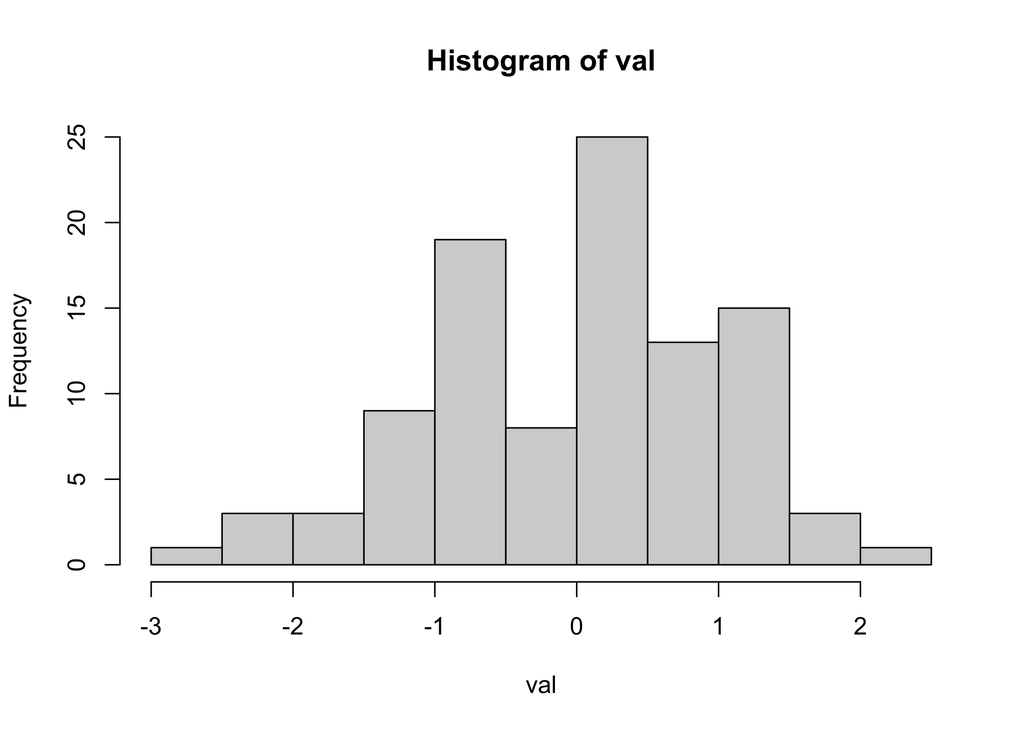

```r
# Simulates 100 observations from a normal distribution
# and plots a histogram
val <- rnorm(n = 100)
hist(val)
```

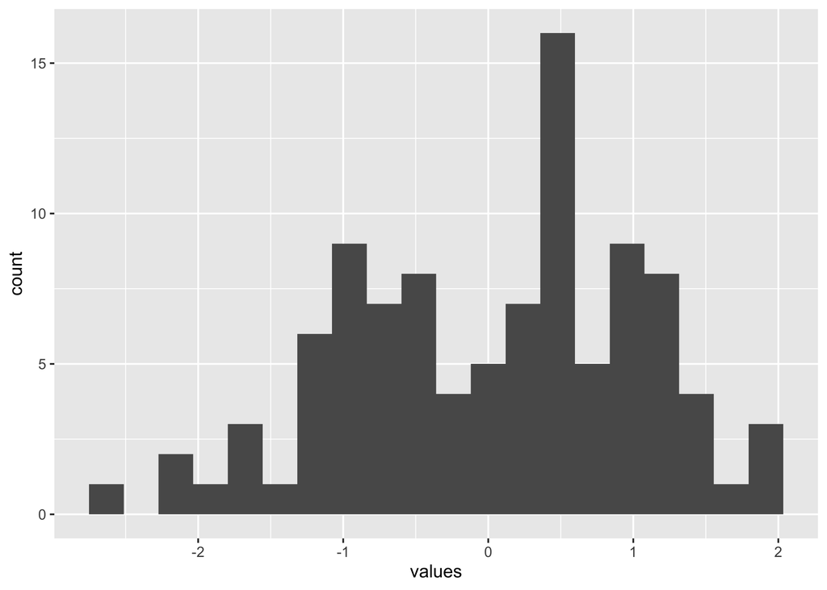

```r
# The ggplot version of the same plot
  ggplot(data = tibble(values = val),
         mapping = aes(x = values))+
  geom_histogram(bins = 20)
```

**Important: before running the code below, click Session -> Set Working Directory -> To Source File Location**

## Exercise 3: Reading in Data

The data we will be analyzing is from the PanTHERIA database which is “a global species-level data set of key life-history, ecological and geographical traits of all known extant and recently extinct mammals (PanTHERIA) developed for a number of macroecological and macroevolutionary research projects.”

```r
# The data is spread across 3 sheets in an excel file. We need to
# combine these data into one table/data frame.

# na = "NA" tells read_xlsx how missing values appear in the data
# the default is empty cells. Run "?read_xlsx" for more info
sheet1 <- read_xlsx(path = "PanTHERIA.xlsx", sheet = 1, na = "NA")
sheet2 <- read_xlsx(path = "PanTHERIA.xlsx", sheet = 2, na = "NA")
sheet3 <- read_xlsx(path = "PanTHERIA.xlsx", sheet = 3, na = "NA")

# rbind (row-bind) combines data frames by row
pantheria <- rbind(sheet1, sheet2, sheet3)
```

```r
# How many rows and columns are there?
nrow(pantheria)
```

```
## [1] 2161
```

```r
ncol(pantheria)
```

```
## [1] 54
```

```r
# What does the data look like?
head(pantheria)
```

```
## # A tibble: 6 × 54
##   Order     Family          Genus Species Binomial ActivityCycle AdultBodyMass_g
##   <chr>     <chr>           <chr> <chr>   <chr>    <chr>                   <dbl>
## 1 Carnivora Canidae         Canis latrans Canis l… crepuscular            11989.
## 2 Carnivora Canidae         Canis lupus   Canis l… crepuscular            31757.
## 3 Carnivora Canidae         Canis simens… Canis s… diurnal                14362.
## 4 Carnivora Canidae         Atel… microt… Atelocy… <NA>                    8363.
## 5 Cetacea   Balaenopteridae Bala… muscul… Balaeno… <NA>               154321304.
## 6 Cetacea   Balaenopteridae Bala… physal… Balaeno… <NA>                47506008.
## # ℹ 47 more variables: AdultForearmLen_mm <dbl>, AdultHeadBodyLen_mm <dbl>,
## #   AgeatEyeOpening_d <dbl>, AgeatFirstBirth_d <dbl>,
## #   BasalMetRate_mLO2hr <dbl>, BasalMetRateMass_g <dbl>, DietBreadth <dbl>,
## #   DispersalAge_d <dbl>, GestationLen_d <dbl>, HabitatBreadth <dbl>,
## #   HomeRange_km2 <dbl>, HomeRange_Indiv_km2 <dbl>, InterbirthInterval_d <dbl>,
## #   LitterSize <dbl>, LittersPerYear <dbl>, MaxLongevity_m <dbl>,
## #   NeonateBodyMass_g <dbl>, NeonateHeadBodyLen_mm <dbl>, …
```

## Exercise 4: Filtering and Reformatting Data

We will exploring adult body mass from these mammals as it relates to their trophic level using `dpylr` and `ggplot2`. Download the cheatsheets for these packages at the following links:

- [dplyr cheatsheet](https://posit.co/wp-content/uploads/2022/10/data-transformation-1.pdf)
- [ggplot2 cheatsheet](https://posit.co/wp-content/uploads/2022/10/data-visualization-1.pdf)

Let’s start by subsetting the data with `select()`

```r
# Pipes (%>%) work by passing the data in front of the pipe to the first argument
# of the function after it, this prevents a lot of nested function calls and makes
# code easier to read.

pantheria <- pantheria %>%     # Passes pantheria as the first argument of select
  select(Order,
         Family,               # select returns the specified columns
         Genus,
         Species,
         TrophicLevel,
         AdultBodyMass_g) %>%
  drop_na() %>%                # Remove any rows that have NAs
  distinct()                   # Remove any duplicate rows
```

Data is almost never clean, for example there should be only 3 trophic levels:

```r
unique(pantheria$TrophicLevel) # unique elements of a vector
```

```
## [1] "carnivore" "herbivore" "omnivore"  "Omnivore"
```

Let’s fix the TrophicLevel column using `mutate()`

```r
# mutate allows us to add columns or modify existing ones
pantheria <- pantheria %>%
  mutate(TrophicLevel = tolower(TrophicLevel)) # Make column lowercase
```

## Exercise 5: Summarizing data

Now we can summarize the adult body mass by trophic level by computing standard metrics like mean and standard deviation.

```r
pantheria %>%
  group_by(TrophicLevel) %>%                            # Group observations by this column
  summarize(Mean = mean(AdultBodyMass_g),               # Summarize will calculate these group wise
            `Standard Deviation` = sd(AdultBodyMass_g), # Quasi quotation lets us add spaces to column names
            Min = min(AdultBodyMass_g),
            Max = max(AdultBodyMass_g)) %>%
  ungroup() %>%
  arrange(desc(Mean))                                   # Order the data frame by descending mean body mass
```

```
## # A tibble: 3 × 5
##   TrophicLevel    Mean `Standard Deviation`   Min        Max
##   <chr>          <dbl>                <dbl> <dbl>      <dbl>
## 1 carnivore    824948.             7963841.  1.96 154321304.
## 2 omnivore      77419.             1173853.  3.29  27324024.
## 3 herbivore     59854.              305498.  5.55   4750000.
```

## Exercise 6: Plotting Data

According to the table above, body masses have a really wide range across trophic levels. Let’s visualize the distribution of adult body masses.

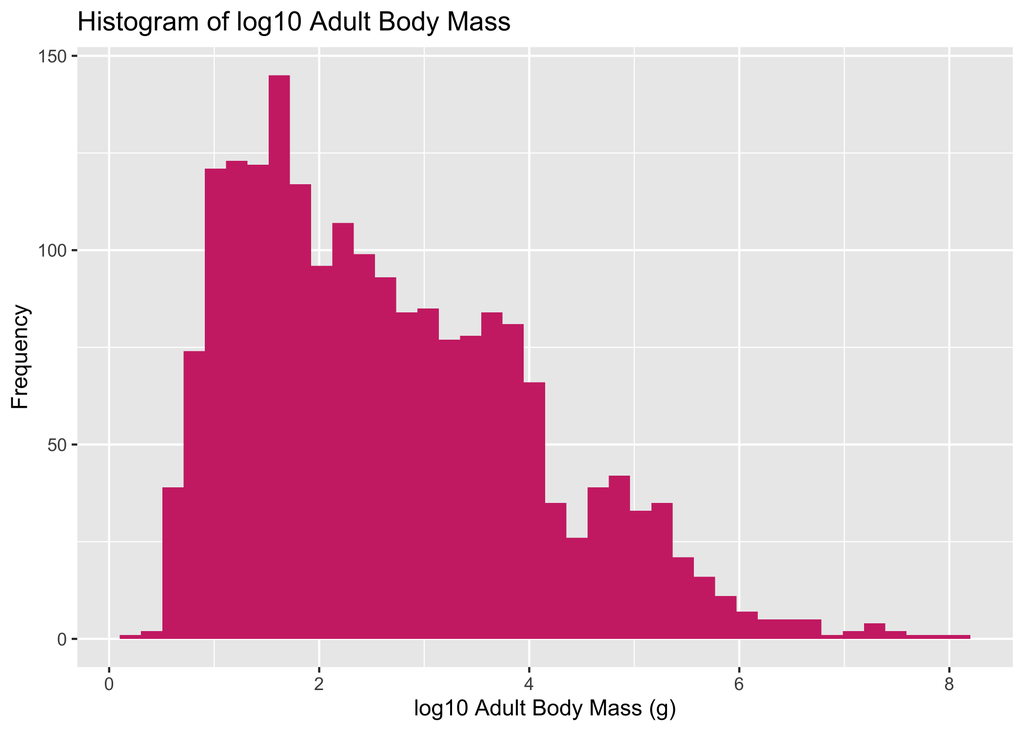

```r
# ggplot2 constructs graphics in layers, each layer is separated by "+"
# x and y values are supplied in aes(), the type of plot is specified using
# the "geom" functions

ggplot(data = pantheria,                             # input data
       mapping =  aes(x = log10(AdultBodyMass_g))) + # log10 transform adult body mass
  geom_histogram(fill = "#CE3274",                   # type of plot
                 bins = 40) +
  xlab(label = "log10 Adult Body Mass (g)") +        # x label
  ylab(label = "Frequency") +                        # y label
  labs(title = "Histogram of log10 Adult Body Mass") # title
```

The data looks skewed even after log10 transformation. Let’s view the distribution by trophic level.

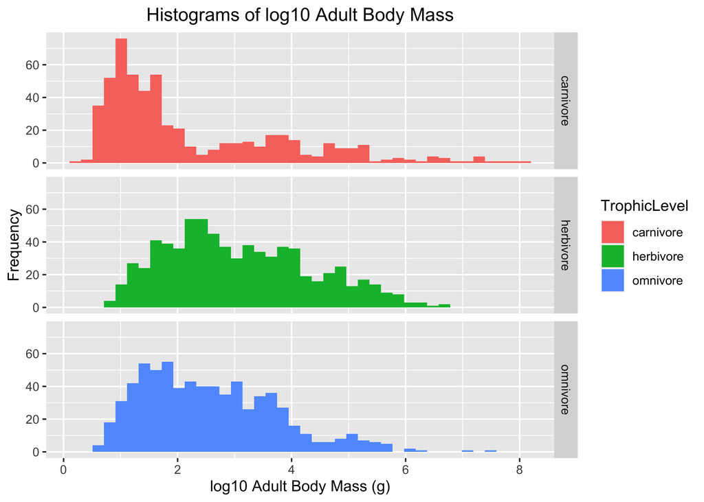

```r
pantheria %>%
  ggplot(aes(x = log10(AdultBodyMass_g), fill = TrophicLevel)) + # Color by trophic level
  geom_histogram(bins = 40) +
  facet_grid(rows = vars(TrophicLevel)) +                        # Split the plot into rows by trophic level
  ylab(label = "Frequency") +
  xlab(label = "log10 Adult Body Mass (g)") +
  labs(title = "Histograms of log10 Adult Body Mass") +
  theme(plot.title = element_text(hjust = 0.5))                  # Center the plot title
```

It is clear that trophic level does have an impact on the distribution of adult body mass, carnivores tend to be smaller which makes sense because carnivores have higher metabolic demands and so there might be a selection pressure towards smaller carnivores. If we wanted to confirm this by fitting a model, we could use the `lm()` function to fit a linear model.

## Exercise 7.1: Hands on coding

An important caveat of the data is that some Orders of mammals are more biodiverse than others and are therefore over represented in the dataset. Using the `dplyr` cheatsheet, write code generates a table of Orders and what percentage of the data they are. Scroll down to see the hint if you are having trouble.

```r
# Your code
```

*Exercise 7.1 hint: group_by + summarize + arrange*

## Exercise 7.2: Hands on coding

Now that we see what the over represented Orders are, we can plot their body masses by trophic level to see if they are skewing the overall distributions.

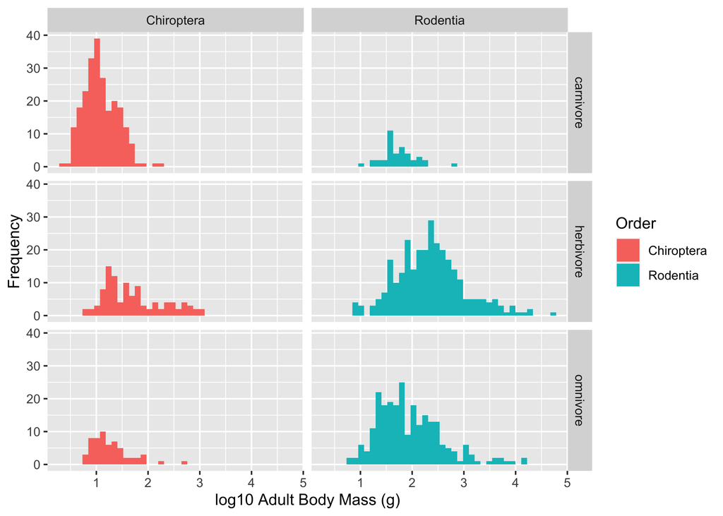

```r
top_orders <- c("Rodentia", "Chiroptera") # Character vector of the top 2 Orders from above
# filter uses a conditional to select rows from the data
pantheria %>%
  filter(Order %in% top_orders) %>%
  ggplot(aes(x = log10(AdultBodyMass_g), fill = Order)) +
  geom_histogram(bins = 40) +
  facet_grid(rows = vars(TrophicLevel),
             cols = vars(Order)) +
  ylab(label = "Frequency") +
  xlab(label = "log10 Adult Body Mass (g)") +
  theme(plot.title = element_text(hjust = 0.5))
```

It looks like one of them is mostly made up of small cornivores. Let’s remove it and redo the plot of body mass distribution by trophic level.

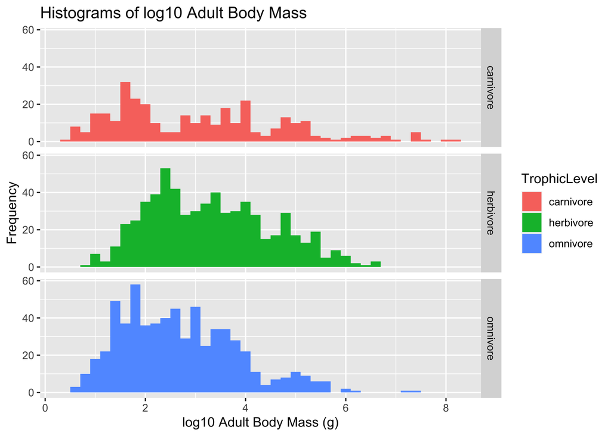

```r
pantheria %>%
  filter(Order != "Chiroptera") %>%
  ggplot(aes(x = log10(AdultBodyMass_g),fill = TrophicLevel)) + # Color by trophic level
  geom_histogram(bins = 40) +
  facet_grid(rows = vars(TrophicLevel)) +                       # Split the plot into rows by trophic level
  ylab(label = "Frequency") +
  xlab(label = "log10 Adult Body Mass (g)") +
  labs(title = "Histograms of log10 Adult Body Mass")
```

We can see now that body mass of carnivorous mammals is much less skewed than the initial plots show. There is still an effect of trophic level on body mass, but the effect size is likely much smaller than we would estimate by including all 393 *Chiroptera*. Now that we have generated these plots, we can generate a full report that contains all of the text and code, click `Knit` to render the HTML report.

## End of workshop exercises

Hopefully this workshop has provided a good foundation for you to learn R. If you would like some additional practice, check out the resources on the [workshop wiki](https://github.com/gladstone-institutes/Bioinformatics-Workshops/wiki/Introduction-to-R-for-Data-Analysis). R also contains many built in datasets you can use for practice:

| Package | Item | Title |
| --- | --- | --- |
| ggplot2 | diamonds | Prices of over 50,000 round cut diamonds |
| ggplot2 | economics | US economic time series |
| ggplot2 | economics_long | US economic time series |
| ggplot2 | faithfuld | 2d density estimate of Old Faithful data |
| ggplot2 | luv_colours | ‘colors()’ in Luv space |
| ggplot2 | midwest | Midwest demographics |
| ggplot2 | mpg | Fuel economy data from 1999 to 2008 for 38 popular models of cars |
| ggplot2 | msleep | An updated and expanded version of the mammals sleep dataset |
| ggplot2 | presidential | Terms of 12 presidents from Eisenhower to Trump |
| ggplot2 | seals | Vector field of seal movements |
| ggplot2 | txhousing | Housing sales in TX |
| tidyr | billboard | Song rankings for Billboard top 100 in the year 2000 |
| tidyr | cms_patient_care | Data from the Centers for Medicare & Medicaid Services |
| tidyr | cms_patient_experience | Data from the Centers for Medicare & Medicaid Services |
| tidyr | construction | Completed construction in the US in 2018 |
| tidyr | fish_encounters | Fish encounters |
| tidyr | household | Household data |
| tidyr | population | World Health Organization TB data |
| tidyr | relig_income | Pew religion and income survey |
| tidyr | smiths | Some data about the Smith family |
| tidyr | table1 | Example tabular representations |
| tidyr | table2 | Example tabular representations |
| tidyr | table3 | Example tabular representations |
| tidyr | table4a | Example tabular representations |
| tidyr | table4b | Example tabular representations |
| tidyr | table5 | Example tabular representations |
| tidyr | us_rent_income | US rent and income data |
| tidyr | who | World Health Organization TB data |
| tidyr | who2 | World Health Organization TB data |
| tidyr | world_bank_pop | Population data from the world bank |

[output cut: 109 more lines]